# Taller de Intervalos de Confianza

# Estadistica

### Febrero de 2020

#### Andrés Felipe Florián e Isabella Martínez

## Introducción

```r
data_set = read.csv("hmnist_28_28_L.csv", header = TRUE, encoding = "UTF-8", sep = ",")
```

## Punto 1

### a)

Se puede calcular el píxel de la mitad de una imágen de $n \times n$ píxeles, dado $n$ par mediante la siguiente fórmula:
$$\frac{n(n-1)}{2}.$$
Así pues, el píxel de la mitad en una im?gen $28 \times 28$ es el 378. Note el resumen estadístico del mismo:

```r
pixel_central <- data_set$pixel0378
summary(pixel_central)
```

```
##    Min. 1st Qu.  Median    Mean 3rd Qu.    Max.
##     6.0    76.0   120.0   136.9   218.2   255.0
```

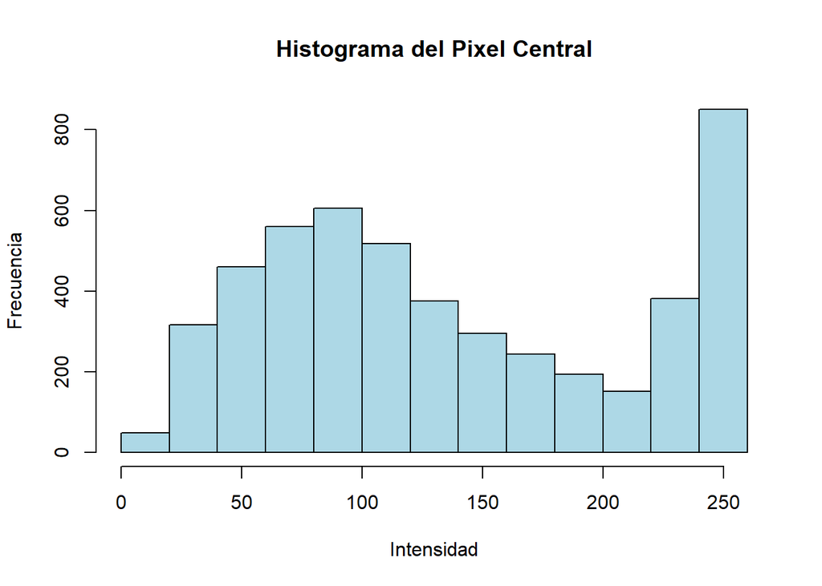

```r
hist(pixel_central, main = "Histograma del Pixel Central", xlab = "Intensidad", ylab = "Frecuencia", col = "Light Blue")
```

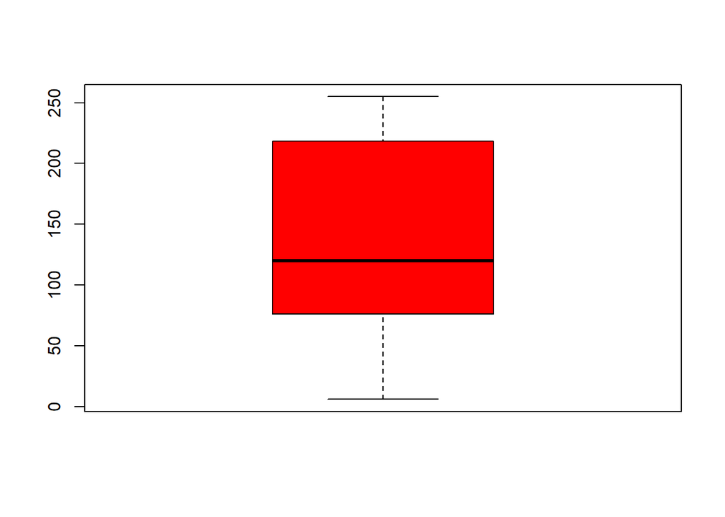

```r
boxplot(pixel_central, col = "Red")
```

### b)

Ahora consideramos los tejidos con cáncer, es decir, aquellos cuyo label es igual a 1.

```r
pc_cancer = data_set$pixel0378[data_set$label == 1]
summary(pc_cancer)
```

```
##    Min. 1st Qu.  Median    Mean 3rd Qu.    Max.
##   10.00   46.00   64.00   75.84   88.00  237.00
```

Considere además su histograma y su diagrama de caja, para ver las frecuencias de las intensidades del píxel en codificación de 8 bits. En el diagrama de caja también se ven los valores atípicos del mismo.

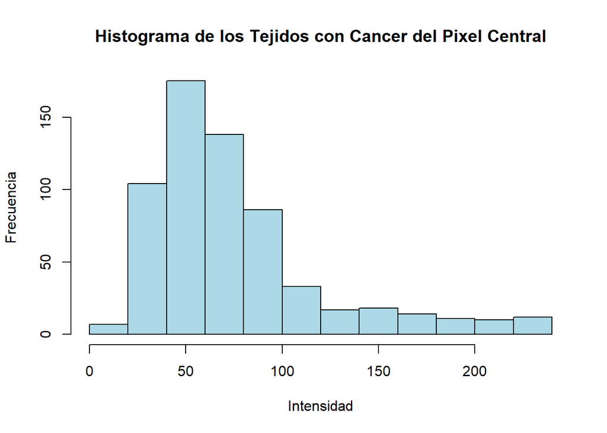

```r
hist(pc_cancer, main = "Histograma de los Tejidos con Cancer del Pixel Central", xlab = "Intensidad", ylab = "Frecuencia", col = "Light Blue")
```

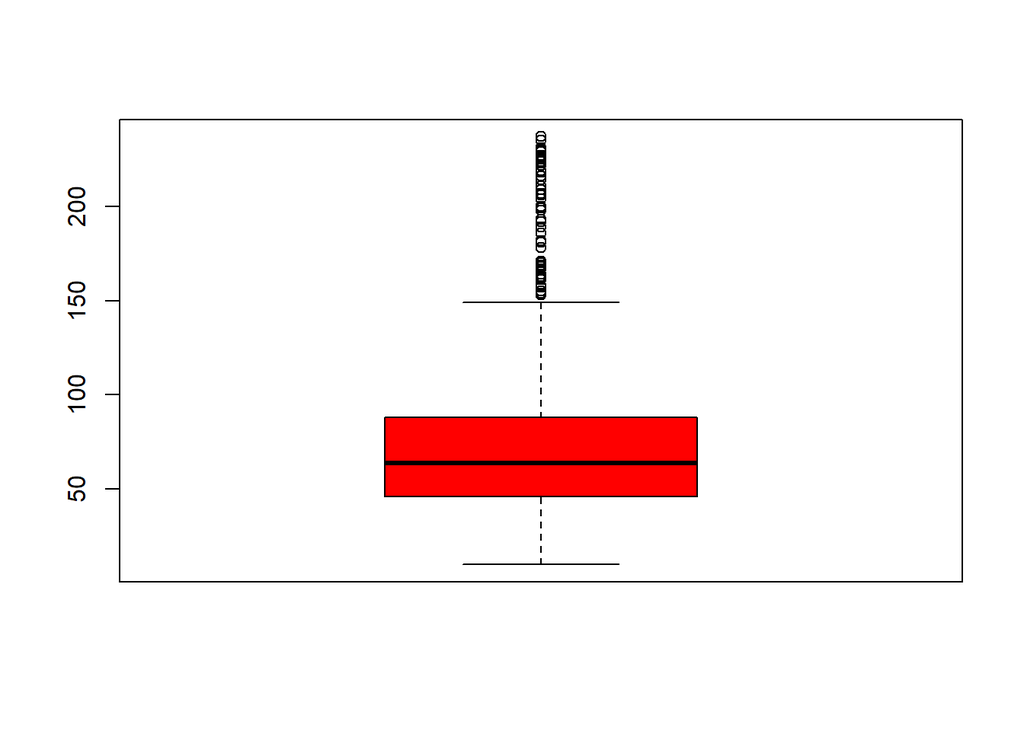

```r
boxplot(pc_cancer, col = "Red")
```

### c)

Ahora consideramos los tejidos que no tienen cáncer, es decir, aquellos cuyo label no es igual a 1.

```r
pc_no_cancer = data_set$pixel0378[data_set$label != 1]
summary(pc_no_cancer)
```

```
##    Min. 1st Qu.  Median    Mean 3rd Qu.    Max.
##     6.0    85.0   132.0   145.6   237.0   255.0
```

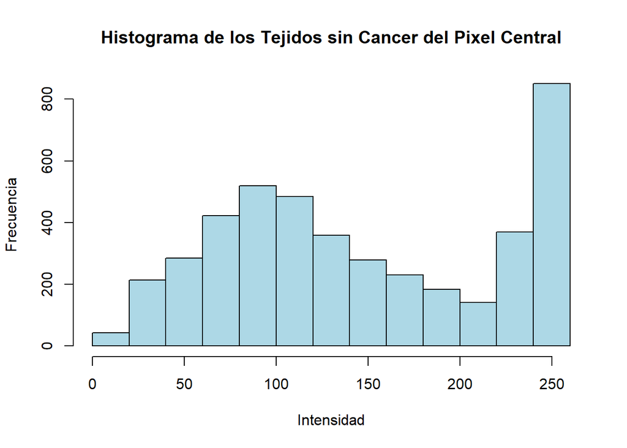

```r
hist(pc_no_cancer, main = "Histograma de los Tejidos sin Cancer del Pixel Central", xlab = "Intensidad", ylab = "Frecuencia", col = "Light Blue")
```

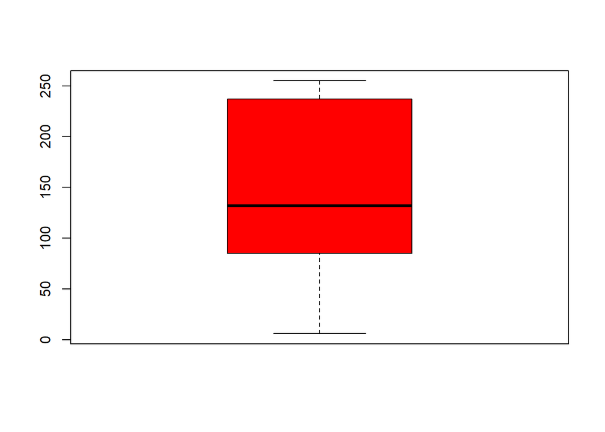

```r
boxplot(pc_no_cancer, col = "Red")
```

### d)

Consideremos ahora al resto de tejidos.

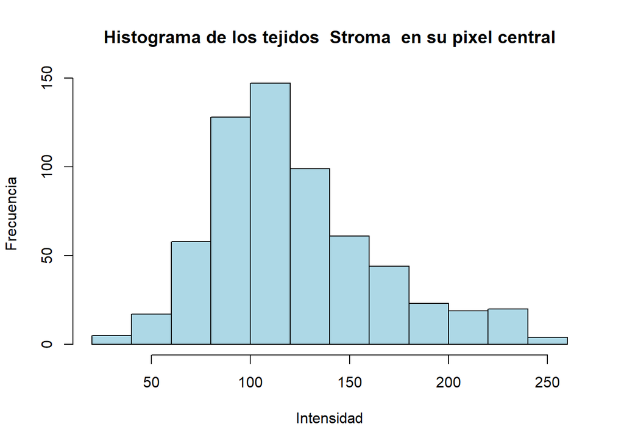

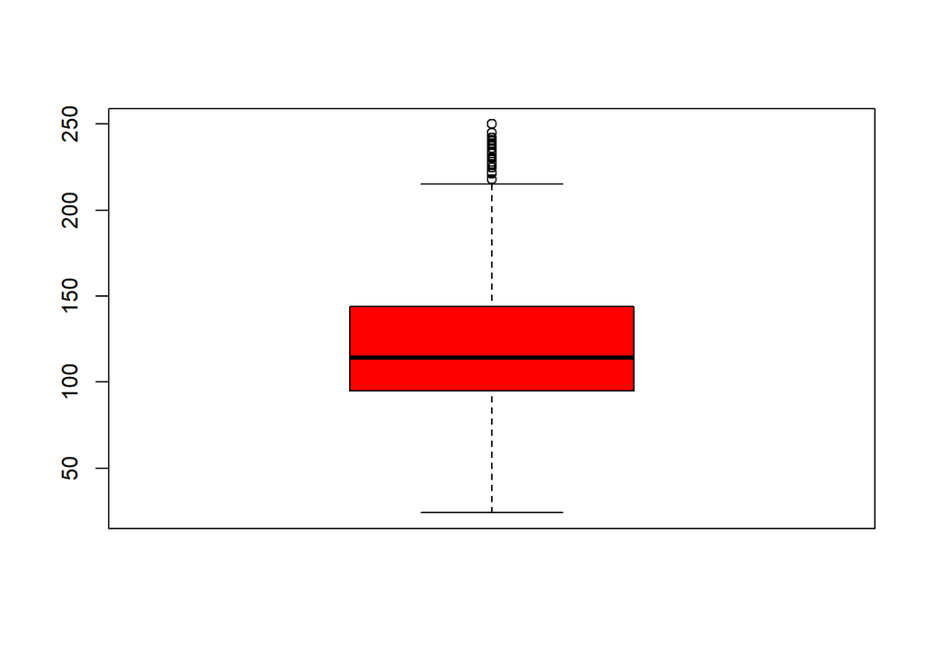

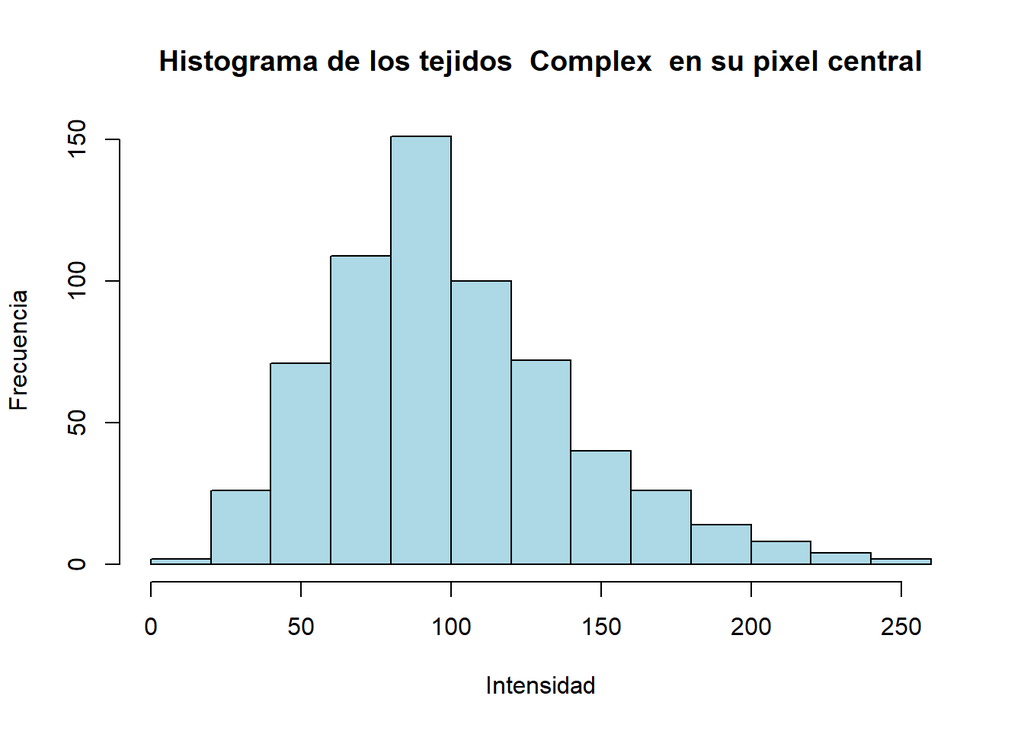

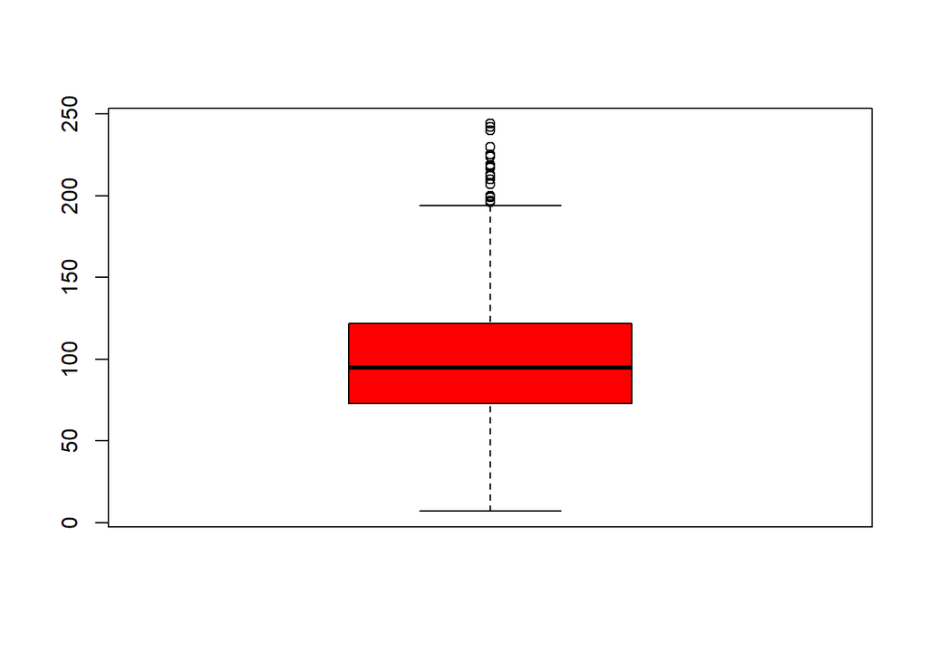

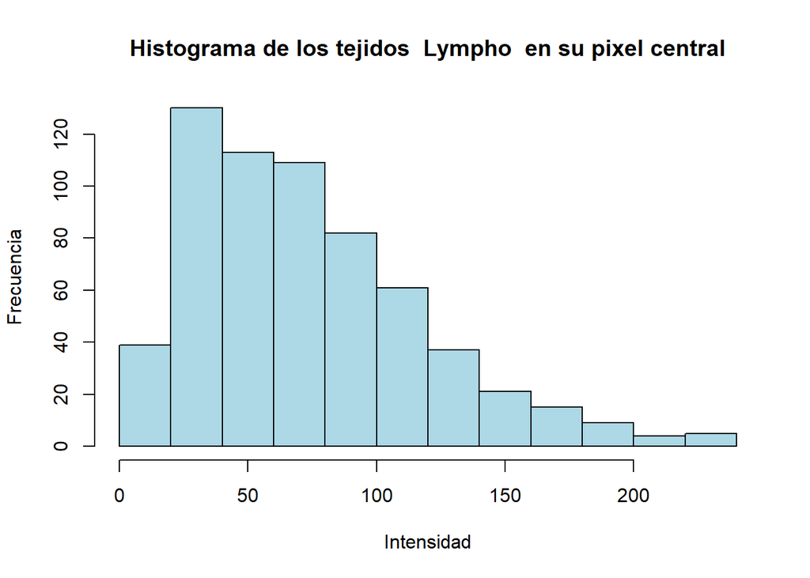

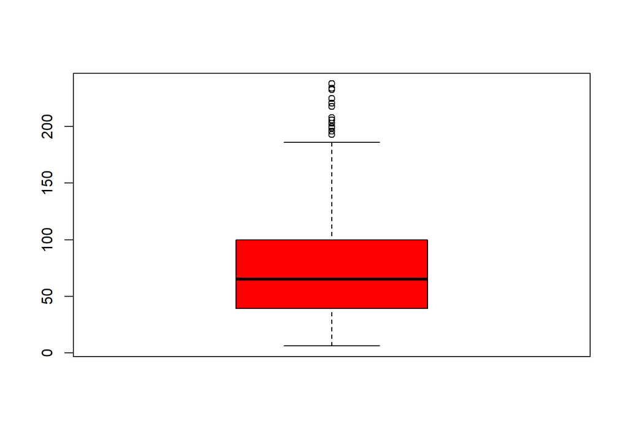

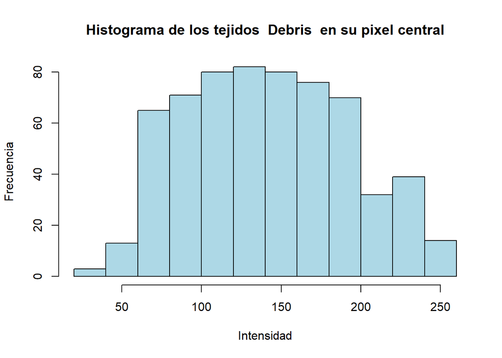

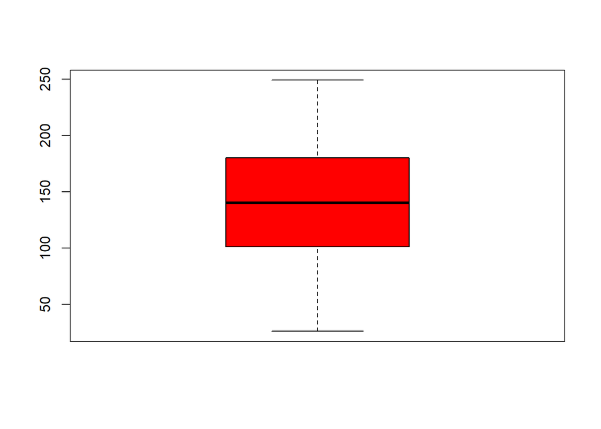

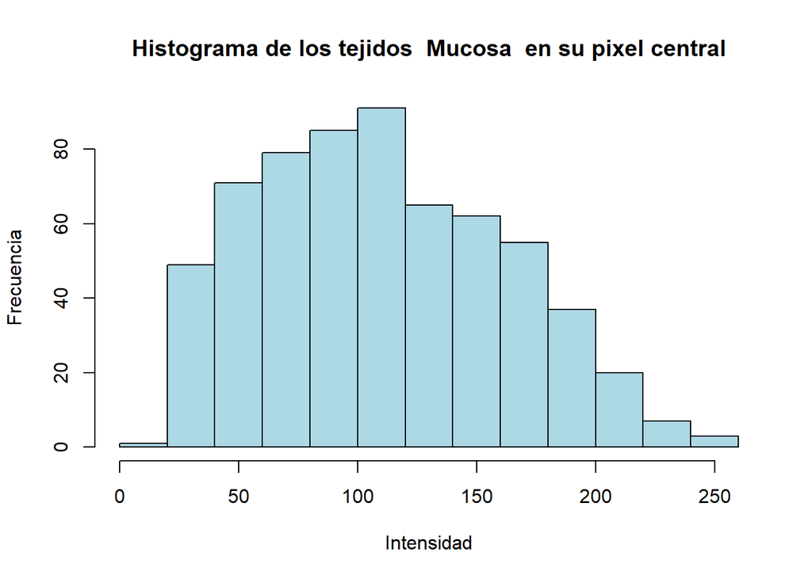

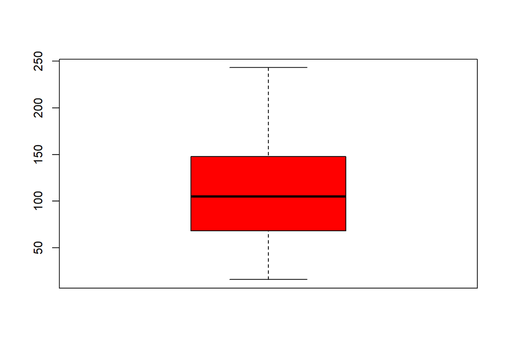

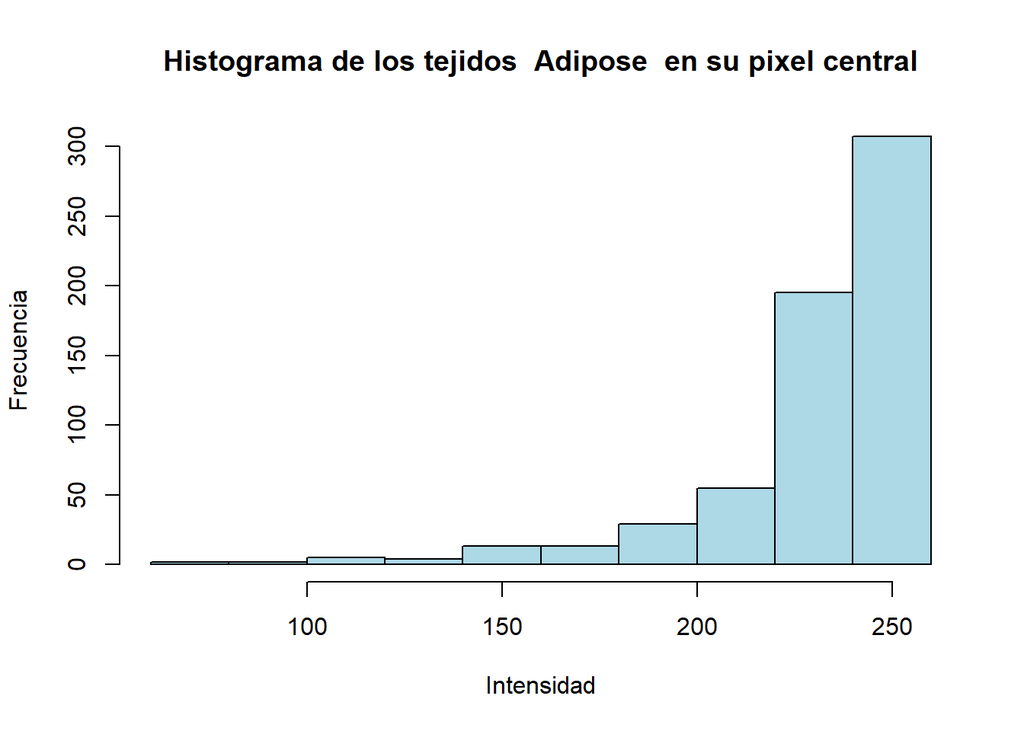

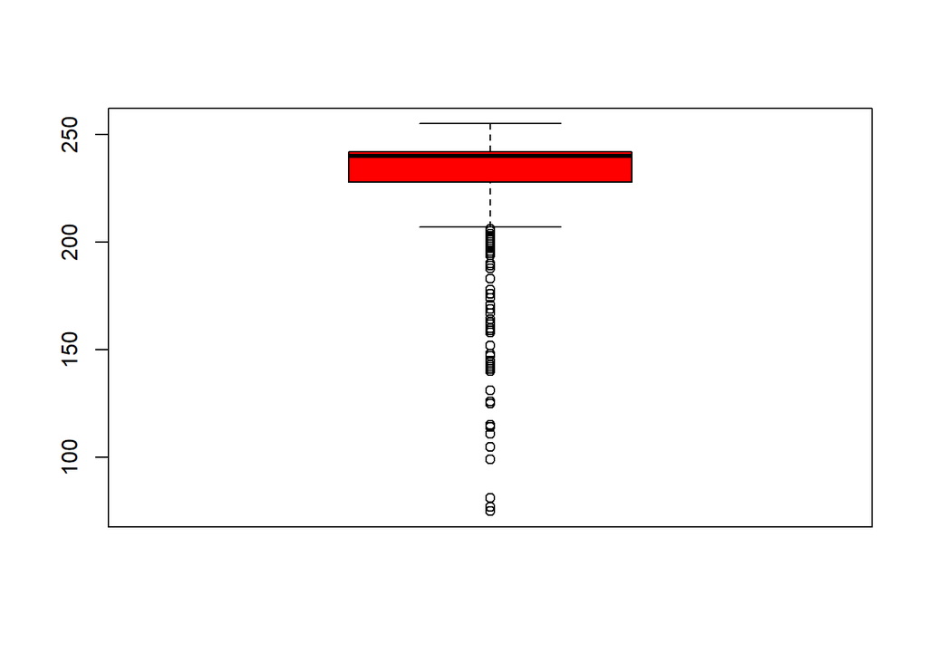

[2 more figures not shown]

```r
tejidos <- c("Stroma","Complex","Lympho","Debris","Mucosa","Adipose","Empty")
for(i in 2:8){
  pc_i = data_set$pixel0378[data_set$label == i]
  summary(pc_i)
  hist(pc_i, main = paste("Histograma de los tejidos ", tejidos[i-1], " en su pixel central"), xlab = "Intensidad", ylab = "Frecuencia", col = "Light Blue")
boxplot(pc_i, col = "Red")

}
```

## Punto 2.

Vamos a graficar una imagen de cada tipo.

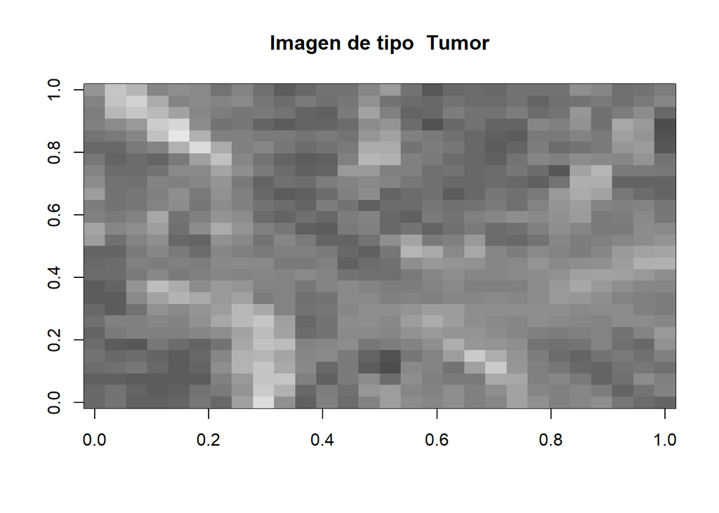

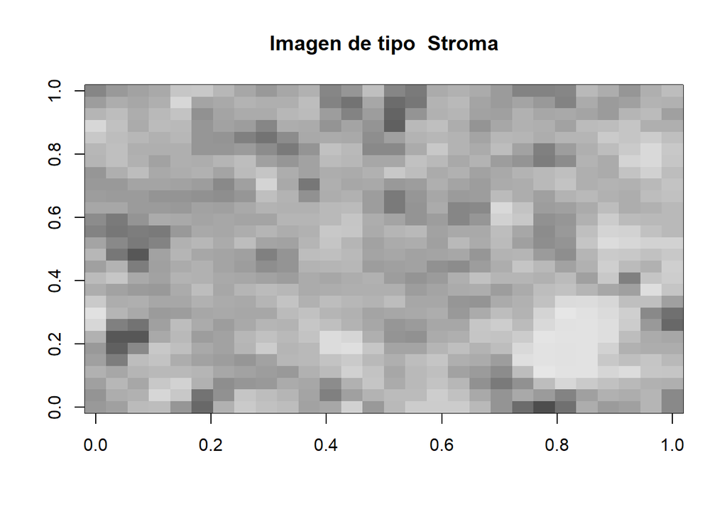

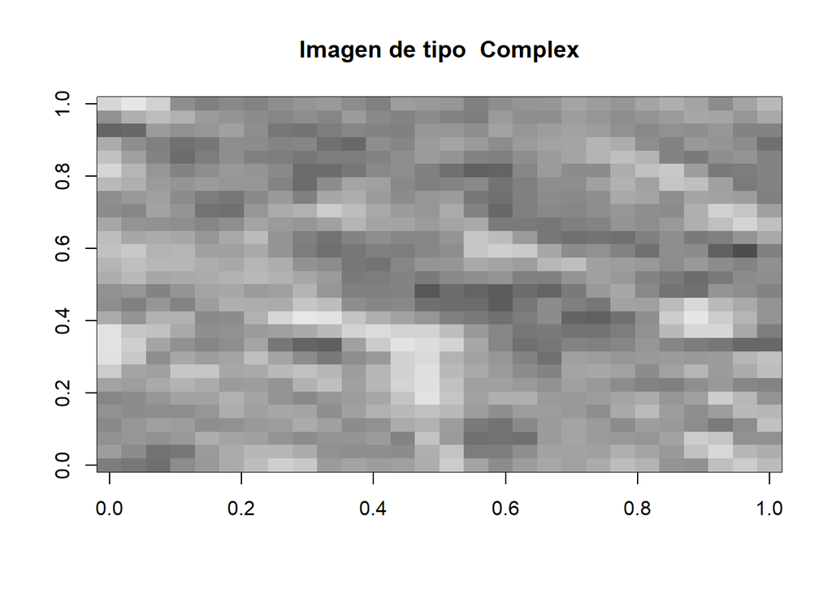

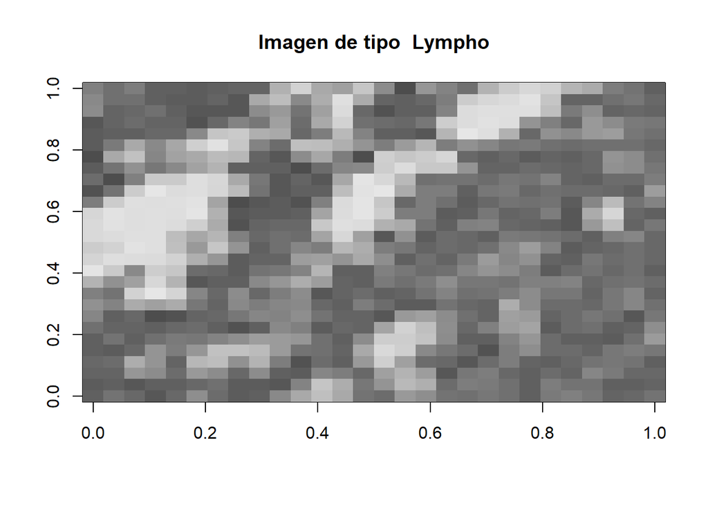

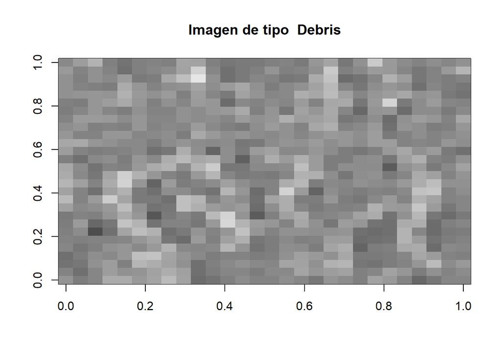

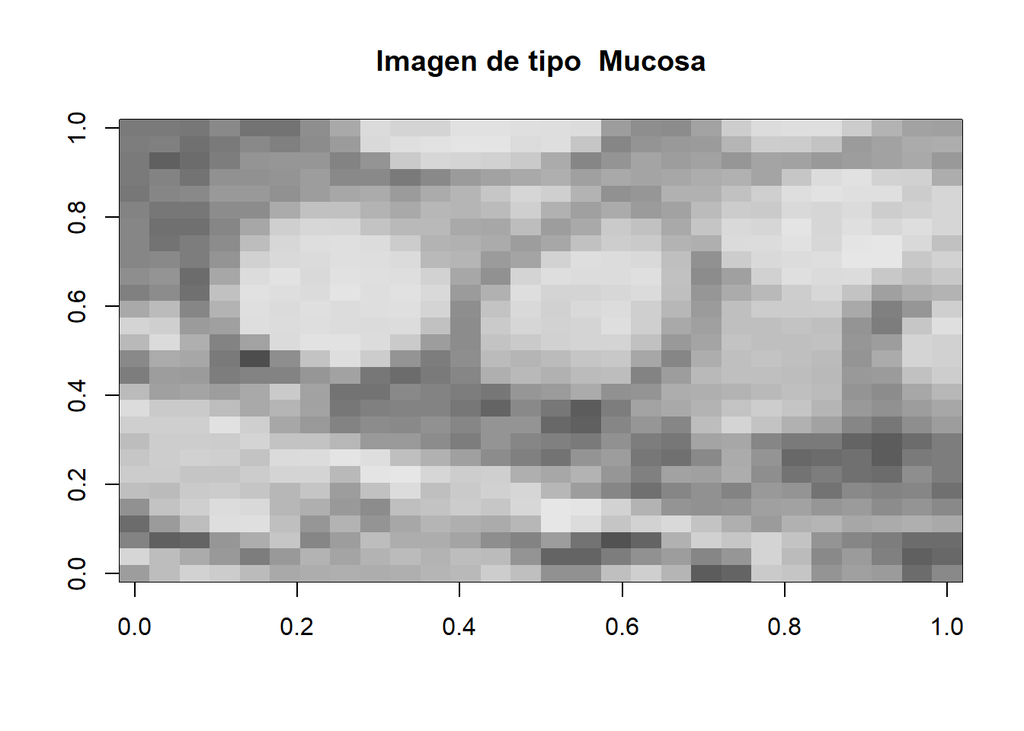

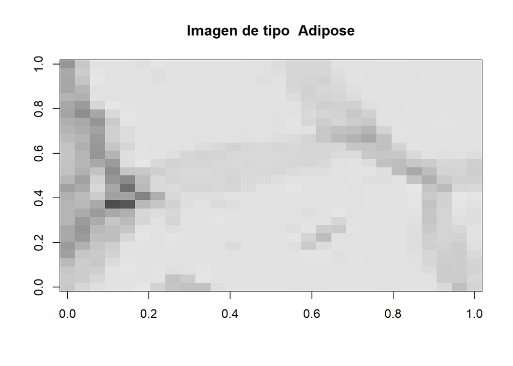

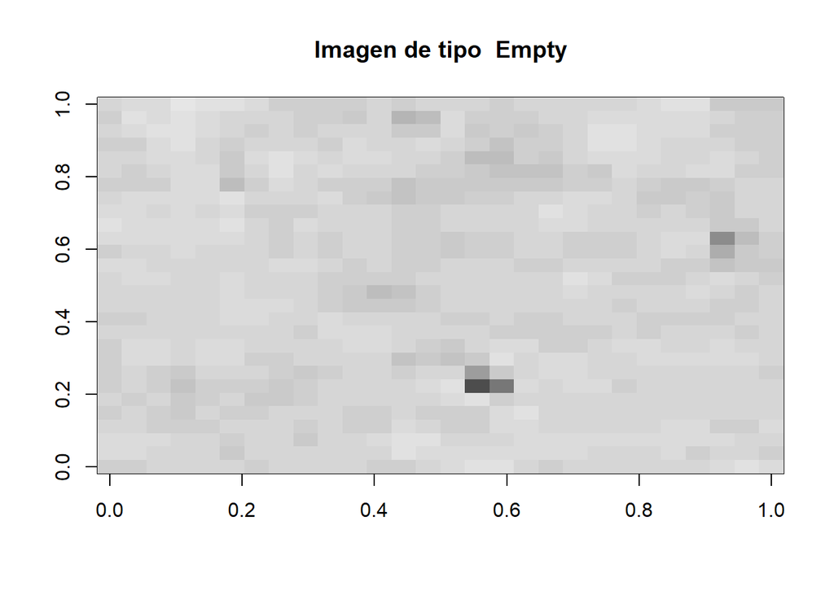

```r
tejidos_t = c("Tumor", "Stroma","Complex","Lympho","Debris","Mucosa","Adipose","Empty")
for(i in 1:8){
  choices = subset(data_set, label == i)
  matriz = matrix(unlist(choices[1,1:784]), byrow = FALSE, nrow = 28)
  image(matriz, col=gray.colors(64), main = paste("Imagen de tipo ", tejidos_t[i]))
}
```

# Punto 3.

Intervalo de confianza del 95% para la media del pixel central.

Tenemos que $1- \alpha = 0.95$, luego $\frac{\alpha}{2} = 0.025$. Como es una muestra grande se aproxima a una normal.

## a)

Para los tejidos con tumor, es decir para los cuales su label es igual a 1.

```r
media = mean(pixel_central[data_set$label == 1], na.rm = TRUE)
n = length(pixel_central)
s = sd(pixel_central, na.rm = TRUE)
z = qnorm(0.025, lower.tail = FALSE)
lim_inf <- media - z*(s/sqrt(n))
lim_sup <- media + z*(s/sqrt(n))
print("IC:")
```

```
## [1] "IC:"
```

```r
d <- c(lim_inf , lim_sup)
d
```

```
## [1] 73.8120 77.8744
```

## b)

Para los tejidos que no son tumor.

```r
media = mean(pixel_central[data_set$label != 1], na.rm = TRUE)
n = length(pixel_central)
s = sd(pixel_central, na.rm = TRUE)
z = qnorm(0.025, lower.tail = FALSE)
lim_inf <- media - z*(s/sqrt(n))
lim_sup <- media + z*(s/sqrt(n))
print("IC:")
```

```
## [1] "IC:"
```

```r
d <- c(lim_inf , lim_sup)
d
```

```
## [1] 143.6115 147.6739
```

## c)

Para los tipos restantes de tejidos.

```r
tejidos <- c("Stroma","Complex","Lympho","Debris","Mucosa","Adipose","Empty")
for(i in 2:8){
  media = mean(pixel_central[data_set$label == i], na.rm = TRUE)
  n = length(pixel_central)
  s = sd(pixel_central, na.rm = TRUE)
  z = qnorm(0.025, lower.tail = FALSE)
  lim_inf <- media - z*(s/sqrt(n))
  lim_sup <- media + z*(s/sqrt(n))
  print(tejidos[i-1])
  d <- c(lim_inf , lim_sup)
  print(d)
}
```

```
## [1] "Stroma"
## [1] 120.3592 124.4216
## [1] "Complex"
## [1]  98.0744 102.1368
## [1] "Lympho"
## [1] 71.6712 75.7336
## [1] "Debris"
## [1] 140.1464 144.2088
## [1] "Mucosa"
## [1] 108.3912 112.4536
## [1] "Adipose"
## [1] 227.0840 231.1464
## [1] "Empty"
## [1] 239.5544 243.6168
```

# Punto 4

## a)

Se tomará una muestra de 200 imágenes aleatoriamente. Note que es posible que en la muestra no se presenten todos los tipos de tejidos. Por consiguiente, si esto se cumple algunos tejidos tendrán valores nulos, o NaN, en sus medias y en sus intervalos de confianza.

```r
muestra <- data_set[sample(nrow(data_set), 200),]
pixel_central = muestra$pixel0378
```

Para los tejidos con tumor, es decir para los cuales su label es igual a 1.

```r
media = mean(pixel_central[muestra$label == 1], na.rm = TRUE)
n = length(pixel_central)
s = sd(pixel_central, na.rm = TRUE)
z = qnorm(0.025, lower.tail = FALSE)
lim_inf <- media - z*(s/sqrt(n))
lim_sup <- media + z*(s/sqrt(n))
print("IC:")
```

```
## [1] "IC:"
```

```r
d <- c(lim_inf , lim_sup)
d
```

```
## [1] 45.32442 65.23558
```

Para los tejidos que no son tumor.

```r
media = mean(pixel_central[muestra$label != 1], na.rm = TRUE)
n = length(pixel_central)
s = sd(pixel_central, na.rm = TRUE)
z = qnorm(0.025, lower.tail = FALSE)
lim_inf <- media - z*(s/sqrt(n))
lim_sup <- media + z*(s/sqrt(n))
print("IC:")
```

```
## [1] "IC:"
```

```r
d <- c(lim_inf , lim_sup)
d
```

```
## [1] 129.8330 149.7442
```

Para los tipos restantes de tejidos.

```r
tejidos <- c("Stroma","Complex","Lympho","Debris","Mucosa","Adipose","Empty")
for(i in 2:8){
  media = mean(pixel_central[muestra$label == i], na.rm = TRUE)
  n = length(pixel_central)
  s = sd(pixel_central, na.rm = TRUE)
  z = qnorm(0.025, lower.tail = FALSE)
  lim_inf <- media - z*(s/sqrt(n))
  lim_sup <- media + z*(s/sqrt(n))
  print(tejidos[i-1])
  d <- c(lim_inf , lim_sup)
  print(d)
}
```

```
## [1] "Stroma"
## [1] 100.6966 120.6078
## [1] "Complex"
## [1]  91.98886 111.90002
## [1] "Lympho"
## [1] 78.39057 98.30173
## [1] "Debris"
## [1] 121.5961 141.5073
## [1] "Mucosa"
## [1]  97.15553 117.06669
## [1] "Adipose"
## [1] 224.2111 244.1222
## [1] "Empty"
## [1] 231.5181 251.4293
```

## b)

Se tomará una muestra de 20 imágenes aleatoriamente. Note que es posible que en la muestra no se presenten todos los tipos de tejidos. Por consiguiente, si esto se cumple algunos tejidos tendrán valores nulos, o NaN, en sus medias y en sus intervalos de confianza.

```r
muestra <- data_set[sample(nrow(data_set), 20),]
pixel_central = muestra$pixel0378
```

Para los tejidos con tumor, es decir para los cuales su label es igual a 1.

```r
media = mean(pixel_central[muestra$label == 1], na.rm = TRUE)
n = length(pixel_central)
s = sd(pixel_central, na.rm = TRUE)
z = qt(0.025, 19,lower.tail = FALSE)
lim_inf <- media - z*(s/sqrt(n))
lim_sup <- media + z*(s/sqrt(n))
print("IC:")
```

```
## [1] "IC:"
```

```r
d <- c(lim_inf , lim_sup)
d
```

```
## [1] 26.52347 90.80987
```

Para los tejidos que no son tumor.

```r
media = mean(pixel_central[muestra$label != 1], na.rm = TRUE)
n = length(pixel_central)
s = sd(pixel_central, na.rm = TRUE)
z = qt(0.025, 19,lower.tail = FALSE)
lim_inf <- media - z*(s/sqrt(n))
lim_sup <- media + z*(s/sqrt(n))
print("IC:")
```

```
## [1] "IC:"
```

```r
d <- c(lim_inf , lim_sup)
d
```

```
## [1] 112.5039 176.7903
```

Para los tipos restantes de tejidos.

```r
tejidos <- c("Stroma","Complex","Lympho","Debris","Mucosa","Adipose","Empty")
for(i in 2:8){
  media = mean(pixel_central[muestra$label == i], na.rm = TRUE)
  n = length(pixel_central)
  s = sd(pixel_central, na.rm = TRUE)
  z = qt(0.025, 19,lower.tail = FALSE)
  lim_inf <- media - z*(s/sqrt(n))
  lim_sup <- media + z*(s/sqrt(n))
  print(tejidos[i-1])
  d <- c(lim_inf , lim_sup)
  print(d)
}
```

```
## [1] "Stroma"
## [1] 121.8568 186.1432
## [1] "Complex"
## [1]  79.1068 143.3932
## [1] "Lympho"
## [1]  53.3568 117.6432
## [1] "Debris"
## [1] 101.8568 166.1432
## [1] "Mucosa"
## [1]  73.8568 138.1432
## [1] "Adipose"
## [1] 209.8568 274.1432
## [1] "Empty"
## [1] 210.1901 274.4765
```

## c)

Ahora generaremos 100 muestras aleatorias de 200 imágenes cada una. Empecemos con los tejidos que tienen tumor, es decir, cuya label es 1.

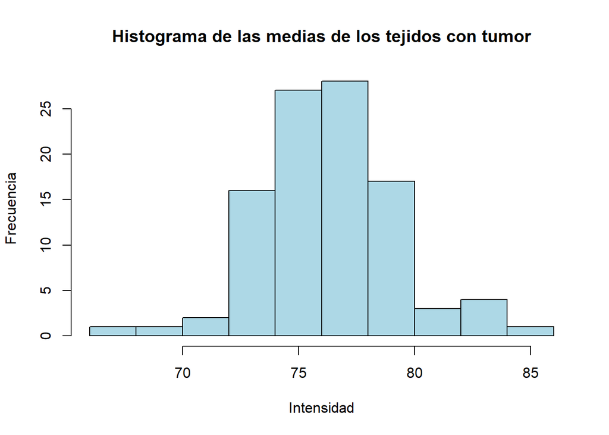

```r
medias_100 = c(rep(0,100))
IC_inf = c(rep(0,100))
IC_sup = c(rep(0,100))
for(i in 1:100){
  interes = subset(data_set, label == 1)
  muestra <- interes[sample(nrow(interes), 200),]
  pixel_central = muestra$pixel0378
  media = mean(pixel_central[muestra$label == 1], na.rm = TRUE)
  medias_100[i] = media
  n = length(pixel_central)
  s = sd(pixel_central[muestra$label == 1], na.rm = TRUE)
  z = qnorm(0.025, lower.tail = FALSE)
  lim_inf <- media - z*(s/sqrt(n))
  lim_sup <- media + z*(s/sqrt(n))
  IC_inf[i] = lim_inf
  IC_sup[i] = lim_sup
}
IC_m = rbind(IC_inf, IC_sup)
mu = mean(medias_100)
hist(medias_100,main = paste("Histograma de las medias de los tejidos con tumor"), xlab = "Intensidad", ylab = "Frecuencia", col = "Light Blue")
```

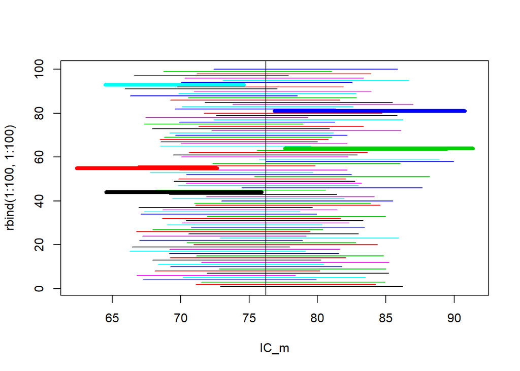

```r
matplot(IC_m, rbind(1:100,1:100), type="l", lty=1)
abline(v=mu)
out = which(!(IC_m[1,] < mu & mu < IC_m[2,]))
matplot(IC_m[,out], rbind(out,out), type = "l",lty =1, add = T, lwd = 5)
```

Ahora los tejidos sin tumor.

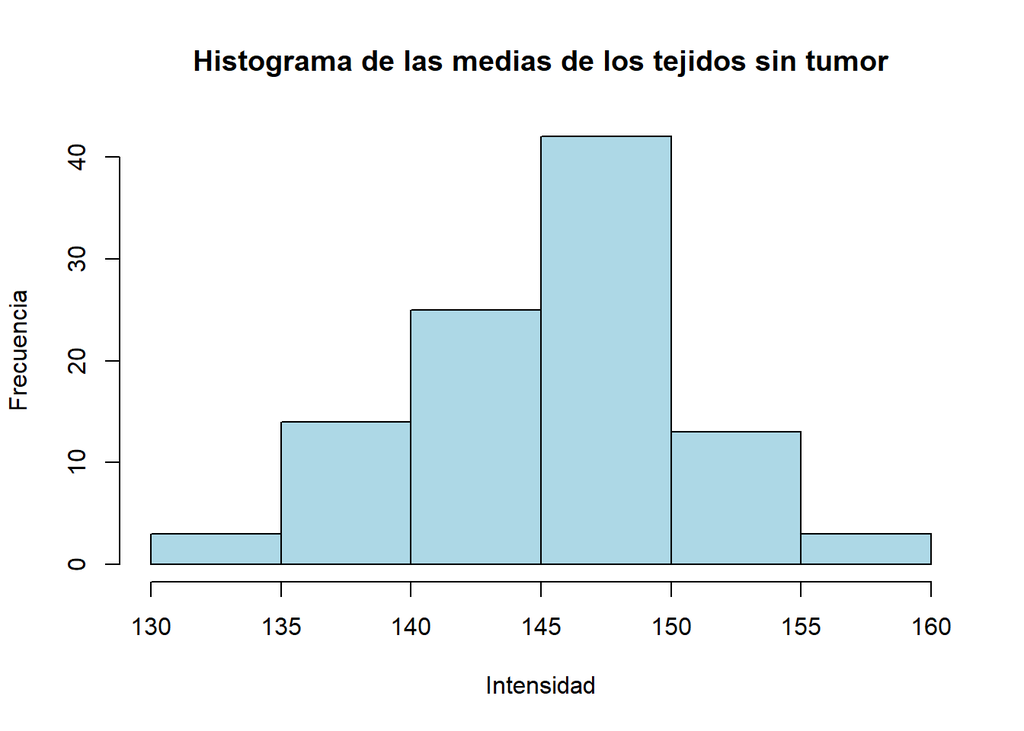

```r
medias_100 = c(rep(0,100))
IC_inf = c(rep(0,100))
IC_sup = c(rep(0,100))
for(i in 1:100){
  interes = subset(data_set, label != 1)
  muestra <- interes[sample(nrow(interes), 200),]
  pixel_central = muestra$pixel0378
  media = mean(pixel_central[muestra$label != 1], na.rm = TRUE)
  medias_100[i] = media
  n = length(pixel_central)
  s = sd(pixel_central[muestra$label != 1], na.rm = TRUE)
  z = qnorm(0.025, lower.tail = FALSE)
  lim_inf <- media - z*(s/sqrt(n))
  lim_sup <- media + z*(s/sqrt(n))
  IC_inf[i] = lim_inf
  IC_sup[i] = lim_sup
}
IC_m = rbind(IC_inf, IC_sup)
mu = mean(medias_100)
hist(medias_100,main = paste("Histograma de las medias de los tejidos sin tumor"), xlab = "Intensidad", ylab = "Frecuencia", col = "Light Blue")
```

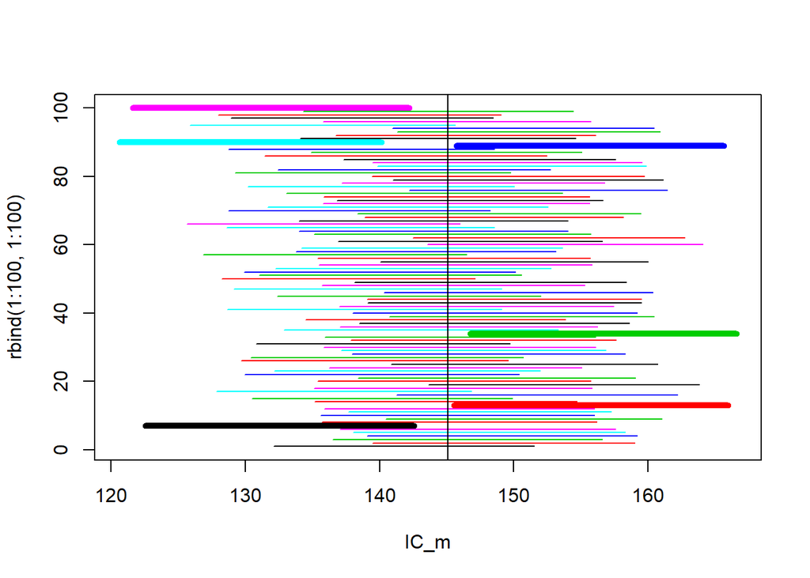

```r
matplot(IC_m, rbind(1:100,1:100), type="l", lty=1)
abline(v=mu)
out = which(!(IC_m[1,] < mu & mu < IC_m[2,]))
matplot(IC_m[,out], rbind(out,out), type = "l",lty =1, add = T, lwd = 5)
```

Y finalmente para el resto de tejidos.